# homework_01_HuaJi

## CMPINF 2120: Homework 01

## Assigned: Tuesday of Week 01 at 11:00PM

## DUE: Tuesday of Week 02 at 11:59PM

This assignment serves two purposes. First, you will review important programming techniques for data manipulation and visualization using Pandas and Seaborn. Second, you will use essential Exploratory Data Analysis (EDA) information to help you begin exploring rather challenging data sets. You will not perform a detailed EDA in this assignment. The goal is for you to see how certain actions may help you begin exploring challenging data sets. You may find such actions helpful when you start exploring data for your final project later in the semester.

You will work with real data throughout this assignment. The first 5 questions are associated with a Wine Ratings data set from Tidy Tuesday. You will also work with a Crops data set from Tidy Tuesday to practice **reshaping** data. Lastly, you will read in data that you choose on your own from the Tidy Tuesday Github repository.

You may add as many code and markdown cells as you see fit to answer the questions.

### Collaborators

Type the names of other students you worked with here.

## Problem 00

Import the "big 4" data analysis modules of NumPy, Pandas, matplotlib pyplot, and Seaborn. You **must** use their common aliases.

#### 0) - SOLUTION

```python
import numpy as np
import pandas as pd
import matplotlib.pyplot as plt

import seaborn as sns
```

## Problem 01

There are many different data repositories available online. The secondary resources table on the Books and Resources page found on the Course website includes many such repositories. You will get experience exploring one repository in this assignment. You will specifically read in data from the Tidy Tuesday Github repo. The repository contains data from many different applications and fields of study. It is especially useful at providing data to practice **Exploratory Data Analysis** (EDA) and most data sets include **data dictionaries** so you may understand the context associated with the variables. Tidy Tuesday is organized by year and new data are uploaded on a weekly basis. The repository dates back to 2018 and so there are hundreds of data sets that you can look through! The Tidy Tuesday Github repo is linked below for your reference.

https://github.com/rfordatascience/tidytuesday

You will begin the assignment by exploring the Wine Ratings data which was uploaded 2019-05-28. The link to that data's repo page is provided below if you are interested to look through it.

https://github.com/rfordatascience/tidytuesday/tree/master/data/2019/2019-05-28

However, you cannot read data from the above link. Instead, data on Github are read from the **raw** pages which contain the "raw" data. The cell below defines the `wine_url` object for you. This object is a string and provides the download link to the "raw" Wine Ratings data. Please note that this data set is **different** from the Wine data explored in CMPINF 2100.

```python
wine_url = 'https://raw.githubusercontent.com/rfordatascience/tidytuesday/master/data/2019/2019-05-28/winemag-data-130k-v2.csv'
```

### 1a)

Use the `pd.read_csv()` function to read the wine data from the Github repo webpage. Assign the result to the `wine` object.

#### 1a) - SOLUTION

```python
wine =pd.read_csv(wine_url)
```

### 1b)

You must now examine the ESSENTIAL EDA information associated with `wine`!

How many rows and columns are associated with the `wine` data set?

#### 1b) - SOLUTION

```python
wine.info()
```

```
<class 'pandas.core.frame.DataFrame'>
RangeIndex: 129971 entries, 0 to 129970
Data columns (total 14 columns):
 #   Column                 Non-Null Count   Dtype
---  ------                 --------------   -----
 0   Unnamed: 0             129971 non-null  int64
 1   country                129908 non-null  object
 2   description            129971 non-null  object
 3   designation            92506 non-null   object
 4   points                 129971 non-null  int64
 5   price                  120975 non-null  float64
 6   province               129908 non-null  object
 7   region_1               108724 non-null  object
 8   region_2               50511 non-null   object
 9   taster_name            103727 non-null  object
 10  taster_twitter_handle  98758 non-null   object
 11  title                  129971 non-null  object
 12  variety                129970 non-null  object
 13  winery                 129971 non-null  object
dtypes: float64(1), int64(2), object(11)
memory usage: 13.9+ MB
```

```python
wine.shape
```

```
(129971, 14)
```

There are 129971 rows and 14 columns are associated with the wine data set.

### 1c)

What are the names of the variables (columns) in `wine`? Display the names to the screen.

#### 1c) - SOLUTION

```python
wine.columns
```

```
Index(['Unnamed: 0', 'country', 'description', 'designation', 'points',
       'price', 'province', 'region_1', 'region_2', 'taster_name',
       'taster_twitter_handle', 'title', 'variety', 'winery'],
      dtype='object')
```

### 1d)

What are the data types associated with each variable (column) in `wine`?

How many variables are associated with each unique data type?

#### 1d) - SOLUTION

```python
wine.dtypes
```

```
Unnamed: 0                 int64
country                   object
description               object
designation               object
points                     int64
price                    float64
province                  object
region_1                  object
region_2                  object
taster_name               object
taster_twitter_handle     object
title                     object
variety                   object
winery                    object
dtype: object
```

```python
wine.dtypes.value_counts()
```

```
object     11
int64       2
float64     1
Name: count, dtype: int64
```

### 1e)

How many unique values are associated with each variable (column) in `wine`?

#### 1e) - SOLUTION

```python
wine.nunique()
```

```
Unnamed: 0               129971
country                      43
description              119955
designation               37979
points                       21
price                       390
province                    425
region_1                   1229
region_2                     17
taster_name                  19
taster_twitter_handle        15
title                    118840
variety                     707
winery                    16757
dtype: int64
```

### 1f)

How many MISSING entries are associated with each variable (column) in `wine`?

#### 1f) - SOLUTION

```python
wine.isna().sum()
```

```
Unnamed: 0                   0
country                     63
description                  0
designation              37465
points                       0
price                     8996
province                    63
region_1                 21247
region_2                 79460
taster_name              26244
taster_twitter_handle    31213
title                        0
variety                      1
winery                       0
dtype: int64
```

## Problem 02

The essential EDA information told you very important properties about `wine`! Did you notice them? Let's find out by visually exploring several of the variables in `wine`.

### 2a)

Create a histogram to visualize the **marginal distribution** of the `points` variable. You must use Seaborn to create the histogram.

#### 2a) - SOLUTION

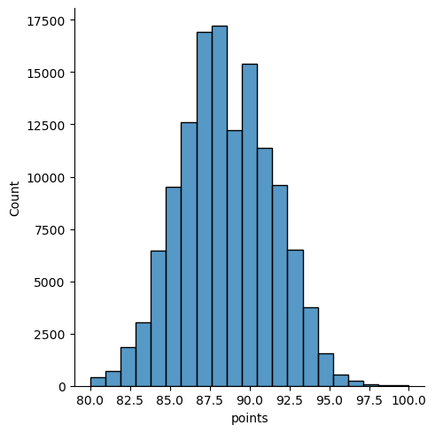

```python
sns.displot(wine, x='points', kind='hist', bins=21)
plt.show()
```

### 2b)

Let's now visualize the distribution of `points` slightly differently. You must create a **bar chart** to visualize the COUNTS associated with each unique value of `points`. You must use Seaborn to create the bar chart.

#### 2b) - SOLUTION

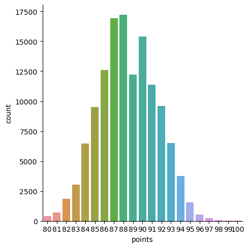

```python
sns.catplot(data =wine, x='points', kind='count')
plt.show()
```

### 2c)

What is the data type of the `points` variable? Why could you use the bar chart to visualize the marginal distribution of `points`? Type your response in a markdown cell below.

#### 2c) - SOLUTION

Type your answer here.

```python
wine.points.dtype
```

```
dtype('int64')
```

The data type of the points variable is integer. Because there is only 21 different points values, so you still can use the bar chart to visualize the marginal distribution of points.

### 2d)

Let's now visualize a different variable. Create a bar chart to show the COUNTS for each unique value for `country`. The bar chart must be created with Seaborn. The bars must be oriented vertically.

#### 2d) - SOLUTION

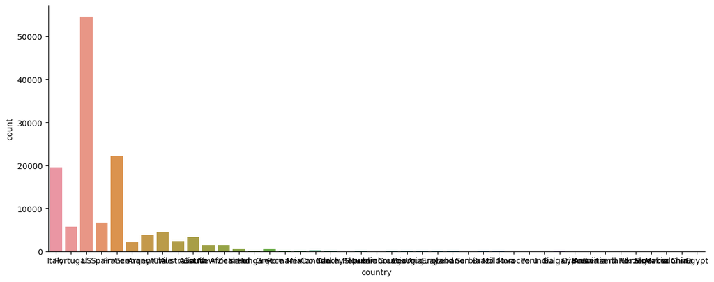

```python
sns.catplot(data =wine, x='country', kind='count',aspect =2.5)
plt.show()
```

### 2e)

Was the **vertical bar chart** difficult to read? Let's try a **horizontal** bar chart instead!

Create a horizontal bar chart to show the COUNTS for each unique value of `country`. The horizontal bar chart must be created with Seaborn.

#### 2e) - SOLUTION

Yes, it's hard to recognize each country use the vertical bar char.

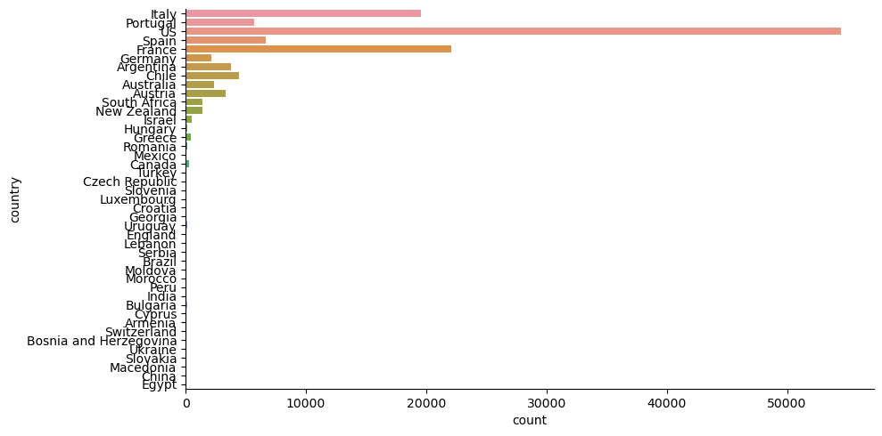

```python
sns.catplot(data =wine, y='country', kind='count',aspect=2)
plt.show()
```

### 2f)

Did the HORIZONTAL bar chart help make the bar chart easier to read? Type your response in a markdown cell below.

#### 2f) - SOLUTION

What do you think?

Yes, the horizontal bar chart help to read each country easily.

### 2g)

The `country` variable is non-numeric. There are other non-numeric variables (columns) in `wine`. As mentioned at the beginning of the assignment, this is not a detailed EDA. Thus, you will not explore all variables in this assignment. You will therefore consider just one more non-numeric variable. You will explore the `variety` column.

How many unique values does `variety` have? Display the value to the screen.

#### 2g) - SOLUTION

```python
wine.variety.nunique()
```

```
707
```

### 2h)

Would you want to create a bar chart for the `variety` column, based on what you have learned so far in this notebook? Type your answer in the markdown cell below.

#### 2h) - SOLUTION

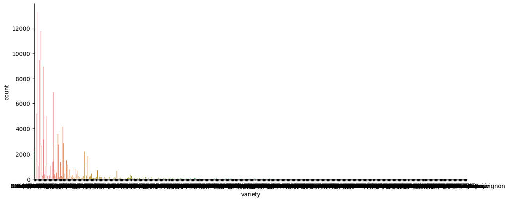

```python
sns.catplot(wine, x='variety', kind='count',aspect =2.5)
plt.show()
```

No, we don't want to create a bar chart for the variety columns since it has 707 unique values.It will be hard to see each unique value using bar chart.

## Problem 03

As you (hopefully) realized by now, the `wine` data has multiple non-numeric variables (columns) that have a large number of unique values! It can feel intimidating to explore and work with such variables. However, we can use Pandas data manipulation techniques to **simplify** the data to help us **begin** our exploration! You will do so by focusing on the **highest count** countries present in `wine`. You will therefore be able to **practice** exploring the data with the small sample size categories removed.

**IMPORTANT!!!** This does **not** mean you should **not** explore small sample size categories! This is to demonstrate a useful **starting** point to help you learn about a portion of the data. The knowledge and understanding gained by focusing on the highest count categories will aid you **later on** when you explore the rest of the data.

There are multiple strategies for identifying the unique values of `country` associated with the highest counts. Let's try several of them now.

### 3a)

Apply the `.value_counts()` method to the `country` column and display the number of rows associated with each unique value of `country`.

#### 3a) - SOLUTION

```python
wine.country.value_counts()
```

```
country
US                        54504
France                    22093
Italy                     19540
Spain                      6645
Portugal                   5691
Chile                      4472
Argentina                  3800
Austria                    3345
Australia                  2329
Germany                    2165
New Zealand                1419
South Africa               1401
Israel                      505
Greece                      466
Canada                      257
Hungary                     146
Bulgaria                    141
Romania                     120
Uruguay                     109
Turkey                       90
Slovenia                     87
Georgia                      86
England                      74
Croatia                      73
Mexico                       70
Moldova                      59
Brazil                       52
Lebanon                      35
Morocco                      28
Peru                         16
Ukraine                      14
Serbia                       12
Czech Republic               12
Macedonia                    12
Cyprus                       11
India                         9
Switzerland                   7
Luxembourg                    6
Bosnia and Herzegovina        2
Armenia                       2
Slovakia                      1
China                         1
Egypt                         1
Name: count, dtype: int64
```

### 3b)

Next, let's practice using the `.groupby().aggregate()` "chain" to apply summary functions to specific columns **grouped by** grouping variables. Specifically, you must group by the `country` column and calculate two summary statistics. The number of rows (size) for each unique value of `country` must be named `num_rows` in a new Pandas DataFrame. Secondly, the number of unique values of `variety` **for each** unique value of `country` must be named `total_varities`.

Assign the result to the `country_info` object. The `country` column **must** be "regular" column and **not** the `.index` attribute associated with the new summarized DataFrame.

#### 3b) - SOLUTION

```python
country_info=wine.groupby(['country']).\
aggregate(num_rows=('country','size'),
           total_varieties=('variety','nunique')
           )
```

### 3c)

Display the `country_info` DataFrame to the screen **sorted** by the `country` with the most number of rows in the original `wine` DataFrame.

#### 3c) - SOLUTION

```python
country_info.sort_values(by=['num_rows'],ascending=False)
```

| country | num_rows | total_varieties |
| --- | --- | --- |
| US | 54504 | 257 |
| France | 22093 | 148 |
| Italy | 19540 | 189 |
| Spain | 6645 | 125 |
| Portugal | 5691 | 92 |
| Chile | 4472 | 62 |
| Argentina | 3800 | 67 |
| Austria | 3345 | 56 |
| Australia | 2329 | 67 |
| Germany | 2165 | 34 |
| New Zealand | 1419 | 27 |
| South Africa | 1401 | 56 |
| Israel | 505 | 48 |
| Greece | 466 | 45 |
| Canada | 257 | 31 |
| Hungary | 146 | 24 |
| Bulgaria | 141 | 23 |
| Romania | 120 | 19 |
| Uruguay | 109 | 16 |
| Turkey | 90 | 24 |
| Slovenia | 87 | 27 |
| Georgia | 86 | 11 |
| England | 74 | 4 |
| Croatia | 73 | 22 |
| Mexico | 70 | 23 |
| Moldova | 59 | 22 |
| Brazil | 52 | 14 |
| Lebanon | 35 | 6 |
| Morocco | 28 | 8 |
| Peru | 16 | 11 |
| Ukraine | 14 | 8 |
| Macedonia | 12 | 8 |
| Serbia | 12 | 6 |
| Czech Republic | 12 | 9 |
| Cyprus | 11 | 4 |
| India | 9 | 3 |
| Switzerland | 7 | 5 |
| Luxembourg | 6 | 4 |
| Armenia | 2 | 2 |
| Bosnia and Herzegovina | 2 | 2 |
| China | 1 | 1 |
| Slovakia | 1 | 1 |
| Egypt | 1 | 1 |

### 3d)

Your summarization efforts should have revealed there a few countries that dominate the counts. There are also multiple countries with very low number of observations. That is why the bar charts were so dominated by just a categories!

Let's simplify things for the rest of the exploration by focusing just the countries with **MORE THAN** 100 observations. Again, please note we are doing this just to help START exploring the data. We are focused on a SUBSET of the data to find interesting patterns associated with them before bringing the small sample size countries back into the exploration.

You therefore need to FILTER the data to a specific set of countries that meet a criterion. Let's begin by defining a list which contains the `country` values (names) associated with all countries that have MORE THAN 100 rows in the `wine` DataFrame. There are multiple ways to accomplish this task. The exact style you want to use is up to you.

Assign the list of countries to "keep" to the `country_keep` object. Display the countries to keep to the screen. How many countries have more than 100 observations in `wine`?

#### 3d) - SOLUTION

```python
country_keep = country_info.loc[country_info.num_rows>100,:].copy()
```

```python
country_keep
```

| country | num_rows | total_varieties |
| --- | --- | --- |
| Argentina | 3800 | 67 |
| Australia | 2329 | 67 |
| Austria | 3345 | 56 |
| Bulgaria | 141 | 23 |
| Canada | 257 | 31 |
| Chile | 4472 | 62 |
| France | 22093 | 148 |
| Germany | 2165 | 34 |
| Greece | 466 | 45 |
| Hungary | 146 | 24 |
| Israel | 505 | 48 |
| Italy | 19540 | 189 |
| New Zealand | 1419 | 27 |
| Portugal | 5691 | 92 |
| Romania | 120 | 19 |
| South Africa | 1401 | 56 |
| Spain | 6645 | 125 |
| US | 54504 | 257 |
| Uruguay | 109 | 16 |

### 3e)

Let's now FILTER the `wine` DataFrame to focus on those countries with more than 100 rows!

Use the appropriate Pandas attribute to FILTER the `wine` DataFrame to rows where `country` IS IN the list of values contained in `country_keep`. Assign the result to the `wine_reduce` object. You must make a DEEP (hard) COPY.

Display the number of unique values of `country` within `wine_reduce` to confirm the filtering behaved as you expected it to.

#### 3e) - SOLUTION

```python
country_keep.index.to_list
```

```
<bound method IndexOpsMixin.tolist of Index(['Argentina', 'Australia', 'Austria', 'Bulgaria', 'Canada', 'Chile',
       'France', 'Germany', 'Greece', 'Hungary', 'Israel', 'Italy',
       'New Zealand', 'Portugal', 'Romania', 'South Africa', 'Spain', 'US',
       'Uruguay'],
      dtype='object', name='country')>
```

```python
wine_reduce = wine.loc[wine.country.isin(country_keep.index),:].copy()
```

```python
wine_reduce.country.nunique()
```

```
19
```

### 3f)

Let's now explore the REDUCED data set with just the HIGH COUNT `country` values!

Create a HORIZONTAL bar chart to show the COUNTS for the unique values of `country` in `wine_reduce`.

You must create the bar chart with Seaborn.

#### 3f) - SOLUTION

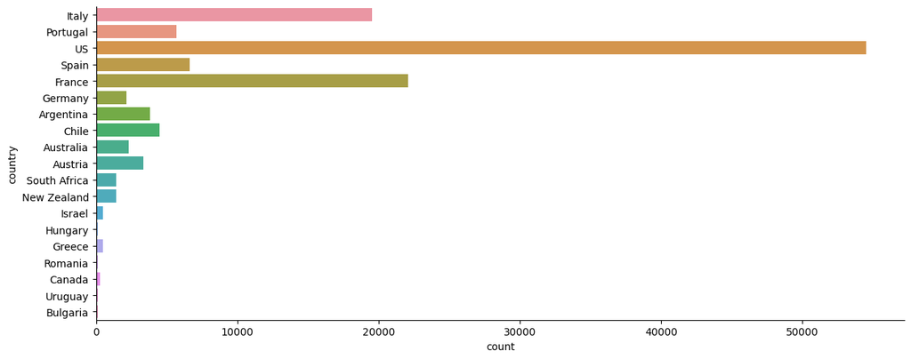

```python
sns.catplot(data =wine_reduce, y='country', kind='count',aspect=2.5)
plt.show()
```

### 3g)

Create a "regular" vertical bar chart to show the COUNTS for the unique values of `points` in `wine_reduce`.

You must create the bar chart with Seaborn.

#### 3g) - SOLUTION

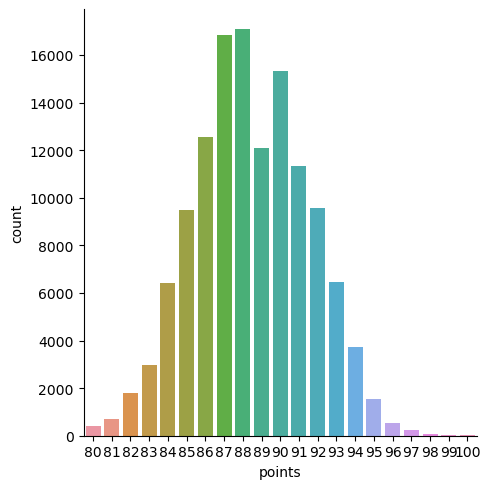

```python
sns.catplot(data =wine_reduce, x='points', kind='count')
plt.show()
```

### 3h)

You have visualized the COUNTS for a non-numeric variable, `country`, and the distribution associated with a numeric variable, `points`. Let's conclude this problem by examining the RELATIONSHIP between the two by examining SUMMARY STATISTICS associated with the **conditional distribution** of `points` **GIVEN** each unique value of `country`! This allows you to examine if `points` are DIFFERENT across the different countries in the REDUCED data set!

Create a BOXPLOT to visualize the SUMMARY STATISTICS of `points` for each unique value of `country` using Seaborn. The boxplot must be oriented HORIZONTALLY.

#### 3h) - SOLUTION

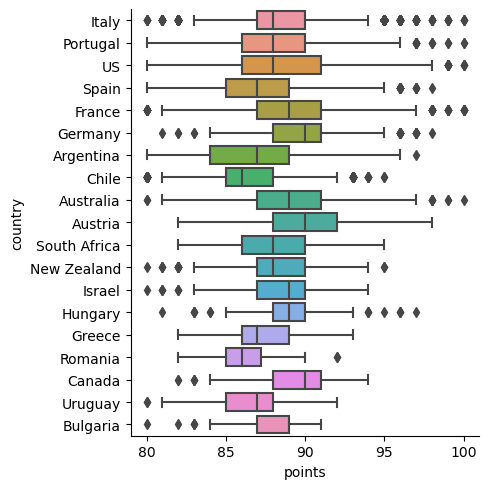

```python
sns.catplot(data=wine_reduce,y='country',x='points',kind='box')
plt.show()
```

### 3i)

Create a POINT PLOT to visualize the CONDITIONAL MEAN (AVERAGE) of `points` for each unique value of `country` using Seaborn. The POINT PLOT must be oriented HORIZONTALLY and the points must **not** be JOINED.

#### 3i) - SOLUTION

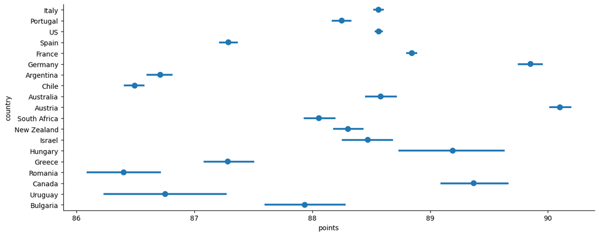

```python
sns.catplot(data=wine_reduce,y='country',x='points',kind='point', join=False,aspect =2.5)
plt.show()
```

### 3j)

The REDUCED data set cannot answer questions associated with ALL countries. But, it does allow you to answer questions about the HIGHEST COUNT countries! You are therefore BEGINNING to find patterns!

Based on your visualizations, which of the HIGHEST COUNT countries has wines with the HIGHEST average `points`? Which of the HIGHEST COUNT countries has wines with the LOWEST average `points`?

Are you confident in your answers? Type your response in a markdown cell below.

#### 3j) - SOLUTION

What do you think?

Based on the visualization, Austria has wine with the HIGHEST average points.Romania has wines with the LOWEST average points. I am not quite confident in the answer since Austria and German's average value overlap with each other and Romania and Chile has overlap in its average value.

## Problem 04

The previous question was focused on the `country` variable. You considered one other non-numeric variable (column) back in Problem 02. You hopefully noticed that `variety` seems like a challenging variable to explore. However, you have performed several actions that will help you begin to explore `variety`! Let's make use of those actions now.

### 4a)

The `country_info` DataFrame includes a column named `total_varities`. This column corresponds to the number of unique values of `variety` for each unique `country`. This column therefore tells you how many varities of wine are associated with each `country` in the data set!

Sort the rows of `country_info` in DESCENDING order by `total_varities` and display the result to the screen.

Which country has the MOST unique varities in the data set?

#### 4a) - SOLUTION

```python
country_info.sort_values(by=['total_varieties'],ascending=False )
```

| country | num_rows | total_varieties |
| --- | --- | --- |
| US | 54504 | 257 |
| Italy | 19540 | 189 |
| France | 22093 | 148 |
| Spain | 6645 | 125 |
| Portugal | 5691 | 92 |
| Argentina | 3800 | 67 |
| Australia | 2329 | 67 |
| Chile | 4472 | 62 |
| Austria | 3345 | 56 |
| South Africa | 1401 | 56 |
| Israel | 505 | 48 |
| Greece | 466 | 45 |
| Germany | 2165 | 34 |
| Canada | 257 | 31 |
| Slovenia | 87 | 27 |
| New Zealand | 1419 | 27 |
| Turkey | 90 | 24 |
| Hungary | 146 | 24 |
| Mexico | 70 | 23 |
| Bulgaria | 141 | 23 |
| Moldova | 59 | 22 |
| Croatia | 73 | 22 |
| Romania | 120 | 19 |
| Uruguay | 109 | 16 |
| Brazil | 52 | 14 |
| Georgia | 86 | 11 |
| Peru | 16 | 11 |
| Czech Republic | 12 | 9 |
| Morocco | 28 | 8 |
| Ukraine | 14 | 8 |
| Macedonia | 12 | 8 |
| Serbia | 12 | 6 |
| Lebanon | 35 | 6 |
| Switzerland | 7 | 5 |
| England | 74 | 4 |
| Luxembourg | 6 | 4 |
| Cyprus | 11 | 4 |
| India | 9 | 3 |
| Armenia | 2 | 2 |
| Bosnia and Herzegovina | 2 | 2 |
| Slovakia | 1 | 1 |
| Egypt | 1 | 1 |
| China | 1 | 1 |

### 4b)

Let's now focus on our attention back on the HIGHEST COUNT countries. Filter the rows of `country_info` to ONLY include the HIGHEST COUNT countries and SORT the remaining rows in DESCENDING order by `total_varities`.

Which country has the FEWEST unique varities out of the set of HIGHEST COUNT countries?

### 4c)

You identified some useful information in the previous problems. However, you have not explore the values associated with `variety` yet. Doing so is challenging, but let's get started by focusing on the varities of wine within a single country. Let's explore the wine varities associated with Romania.

Use the appropriate Pandas attribute to FILTER the `wine` DataFrame to rows where `country` is equal to `'Romania'`. Assign the result to the `romania` object. You must make a DEEP (hard) COPY.

Display the number of unique values of `country` within `romania` to confirm the filtering behaved as you expected it to.

#### 4c) - SOLUTION

```python
country_info.index
```

```
Index(['Argentina', 'Armenia', 'Australia', 'Austria',
       'Bosnia and Herzegovina', 'Brazil', 'Bulgaria', 'Canada', 'Chile',
       'China', 'Croatia', 'Cyprus', 'Czech Republic', 'Egypt', 'England',
       'France', 'Georgia', 'Germany', 'Greece', 'Hungary', 'India', 'Israel',
       'Italy', 'Lebanon', 'Luxembourg', 'Macedonia', 'Mexico', 'Moldova',
       'Morocco', 'New Zealand', 'Peru', 'Portugal', 'Romania', 'Serbia',
       'Slovakia', 'Slovenia', 'South Africa', 'Spain', 'Switzerland',
       'Turkey', 'US', 'Ukraine', 'Uruguay'],
      dtype='object', name='country')
```

```python
romania=wine.loc[wine.country=='Romania',:].copy()
```

```python
romania
```

|  | Unnamed: 0 | country | description | designation | points | price | province | region_1 | region_2 | taster_name | taster_twitter_handle | title | variety | winery |
| --- | --- | --- | --- | --- | --- | --- | --- | --- | --- | --- | --- | --- | --- | --- |
| 306 | 306 | Romania | Fragrant on the nose with fresh orange, lemon ... | NaN | 87 | 7.0 | Recas | NaN | NaN | Anna Lee C. Iijima | NaN | Cramele Recas 2009 Chardonnay (Recas) | Chardonnay | Cramele Recas |
| 984 | 984 | Romania | An intriguing nose of tobacco, mint, cherry an... | Rosso di Valachia | 85 | 12.0 | Dealu Mare | NaN | NaN | Susan Kostrzewa | @suskostrzewa | Byzantium 2005 Rosso di Valachia Red (Dealu Mare) | Red Blend | Byzantium |
| 1543 | 1543 | Romania | This wine is light straw-colored, with aromas ... | Nec Plus Ultra Demisec | 85 | 10.0 | Jidvei | NaN | NaN | Jeff Jenssen | @worldwineguys | Jidvei 2015 Nec Plus Ultra Demisec Sauvignon B... | Sauvignon Blanc | Jidvei |
| 2486 | 2486 | Romania | A blend of 50% Sauvignon Blanc, 40% Feteasca A... | Domaine Ceptura | 88 | 22.0 | Dealu Mare | NaN | NaN | Jeff Jenssen | @worldwineguys | Davino 2013 Domaine Ceptura White (Dealu Mare) | White Blend | Davino |
| 2501 | 2501 | Romania | This wine made from an indigenous Romanian gra... | NaN | 88 | 20.0 | Panciu | NaN | NaN | Jeff Jenssen | @worldwineguys | Domeniile Panciu 2012 Feteasca Neagra (Panciu) | Feteasca Neagra | Domeniile Panciu |
| ... | ... | ... | ... | ... | ... | ... | ... | ... | ... | ... | ... | ... | ... | ... |
| 129078 | 129078 | Romania | Cramele Recas's Dreamfish series of internatio... | Dreamfish | 87 | 7.0 | Viile Timisului | NaN | NaN | Anna Lee C. Iijima | NaN | Cramele Recas 2011 Dreamfish Cabernet Sauvigno... | Cabernet Sauvignon | Cramele Recas |
| 129462 | 129462 | Romania | Dark garnet in color, this wine carries aromas... | Premium | 87 | 12.0 | Dealu Mare | NaN | NaN | Jeff Jenssen | @worldwineguys | Budureasca 2015 Premium Merlot (Dealu Mare) | Merlot | Budureasca |
| 129608 | 129608 | Romania | Hints of rose petals are a curious contrast to... | Vitis Metamorfosis | 84 | 15.0 | Dealu Mare | NaN | NaN | Anna Lee C. Iijima | NaN | Cramele Halewood 2009 Vitis Metamorfosis Merlo... | Merlot | Cramele Halewood |
| 129611 | 129611 | Romania | Darkly toasted oak lends a veil of smoke and c... | Terra Romana | 84 | 10.0 | Dealu Mare | NaN | NaN | Anna Lee C. Iijima | NaN | SERVE 2010 Terra Romana Chardonnay (Dealu Mare) | Chardonnay | SERVE |
| 129624 | 129624 | Romania | Exuberantly fragrant of ripe, tropical fruit a... | Single Vineyard Selection Scurta Vineyard Viog... | 84 | 12.0 | Dealurile Munteniei | NaN | NaN | Anna Lee C. Iijima | NaN | Cramele Halewood 2009 Single Vineyard Selectio... | White Blend | Cramele Halewood |

120 rows × 14 columns

### 4d)

Let's explore the varities of wine from Romania (according to this data set)!

Create a HORIZONTAL bar chart using Seaborn to show the COUNTS associated with each unique value of `variety` within the `romania` DataFrame.

#### 4d) - SOLUTION

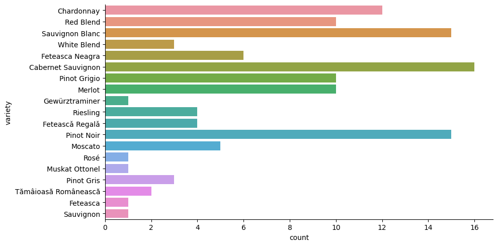

```python
sns.catplot(data=romania, y='variety', kind='count',aspect=2)
plt.show()
```

### 4e)

You have explored a few variables, and you might be wondering why did we focus on just those few? There are many others we could examine in this application. Again, this is not a detailed EDA but let's consider one more variable. The `price` column is the price of the wine. Let's visualize the marginal distribution of `price` for those wines coming from Romania.

Create a histogram in Seaborn to visualize the marginal distribution of `price` for Romanian wines.

What stands out about this distribution?

#### 4e) - SOLUTION

```python
# this is not the answer just help to check the result
romania.price.value_counts()
```

```
price
7.0      32
9.0      23
8.0      12
10.0      9
12.0      8
20.0      8
11.0      5
22.0      4
18.0      4
28.0      3
17.0      2
16.0      2
58.0      2
100.0     1
6.0       1
30.0      1
320.0     1
4.0       1
15.0      1
Name: count, dtype: int64
```

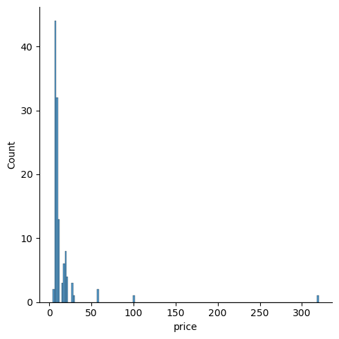

```python
sns.displot(data=romania,x='price',kind='hist')
plt.show()
```

from the histgram we can see that most of the wine's price are around $10.00 or less than $20. Very few is more than $300.

### 4f)

Let's examine how the `price` CHANGES across the values of `variety` for wines in Romania!

Create a BOXPLOT to study the summary statistics associated with `price` for each unique value of `variety`. The boxplot must be HORIZONTALLY oriented and must be created using Seaborn.

What stands out from this boxplot?

#### 4f) - SOLUTION

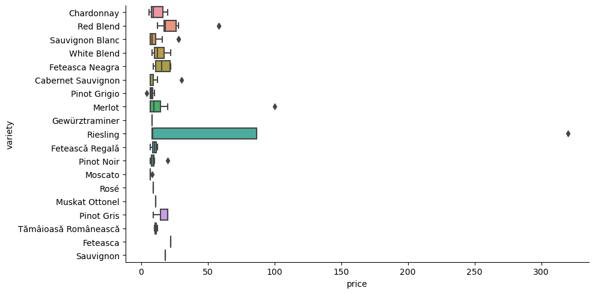

```python
sns.catplot(data=romania, y='variety', x='price', kind='box',aspect=2)
plt.show()
```

From the box plot we can see that some kind of the wine has a big price difference, like Riesling and Meriot. For Riesling, most of the Riesling has the price around $10 and one kind of it has a price a more than $300, which looks like an outlier or extreme value in the boxplot.

### 4g)

Next, let's examine the CONDITIONAL MEAN (AVERAGE) of `price` for each unique value of `variety` for Romanian wines!

Create a POINT PLOT to visualize the CONDITIONAL MEAN (AVERAGE) of `price` for each unique value of `variety` using Seaborn. The POINT PLOT must be oriented HORIZONTALLY and the points must not be JOINED.

What stands out from this POINT PLOT?

#### 4g) - SOLUTION

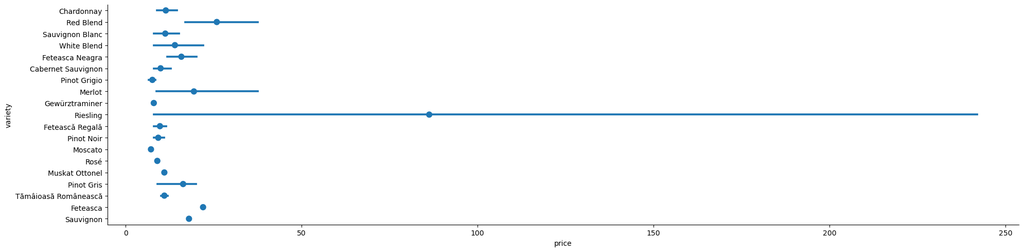

```python
sns.catplot(data=romania, y='variety',x='price',
            kind='point', join=False,aspect=4)
plt.show()
```

The point plot also shows us that the average price of Riesling and Meriot has a big value.

### 4h)

The two previous figures might have had some strange "effects". Several of the strange effects can be explained by ALSO considering the BAR CHART created in 4d) which visualized the COUNTS associated with each unique `variety` value.

Why is that bar chart so useful for interpreting the BOXPLOT and POINT PLOT shown in 4f) and 4g)? Type your response in the markdown cell below.

#### 4h) - SOLUTION

What do you think?

The bar chart can help us to see the price and count relationships.Most of the variety that has a low count usually has a little higher price.

## Problem 05

Let's conclude our introductory EDA of the `wine` data by considering the MISSING entries. A common mistake when exploring data is to DROP or REMOVE missings too early. Let's find out why that is the case!

### 5a)

Apply the appropriate Pandas method to DROP all rows in `wine` with at least 1 MISSING entry. You are therefore creating the COMPLETE CASES data set. Assign the result to the `wine_complete` object. You must make a DEEP (hard) COPY.

Display the number of MISSING entries associated with each variable (column) in `wine_complete` to confirm you successfully created the COMPLETE CASES.

#### 5a) - SOLUTION

```python
wine_complete=wine.dropna().copy()
```

```python
wine_complete.isna().sum()
```

```
Unnamed: 0               0
country                  0
description              0
designation              0
points                   0
price                    0
province                 0
region_1                 0
region_2                 0
taster_name              0
taster_twitter_handle    0
title                    0
variety                  0
winery                   0
dtype: int64
```

### 5b)

How many rows does `wine_complete` have? How many rows were therefore "lost" by DROPPING all MISSINGS?

#### 5b) - SOLUTION

```python
wine_complete.shape[0]
```

```
22387
```

```python
wine.shape[0]-wine_complete.shape[0]
```

```
107584
```

There are 22387 rows in the wine_complete data set. There are 107584 rows lost by dropping all missing.

### 5c)

Let's explore a few variables in the COMPLETE CASES data set.

Visualize the COUNTS associated with each unique value of `country` in the COMPLETE CASES data set, `wine_complete`. The bar chart must be HORIZONTALLY oriented and created using Seaborn.

#### 5c) - SOLUTION

```python
wine_complete.country.nunique()
```

```
1
```

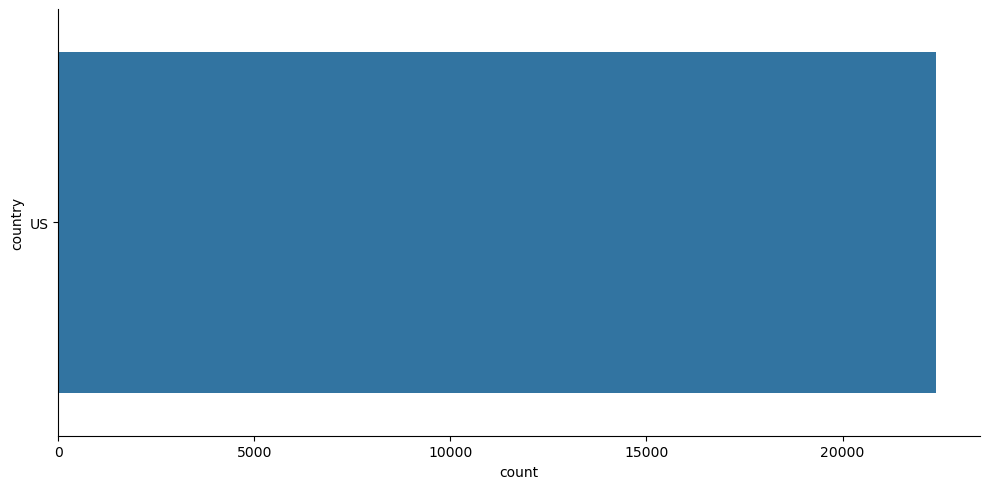

```python
sns.catplot(data=wine_complete,y='country',kind='count',aspect=2)
plt.show()
```

### 5d)

Create a BOXPLOT to visualize the conditional summary statistics of `points` for each unique value of `country` in the COMPLETE CASES data set, `wine_complete`. The BOXPLOT must be HORIZONTALLY oriented and created using Seaborn.

#### 5d) - SOLUTION

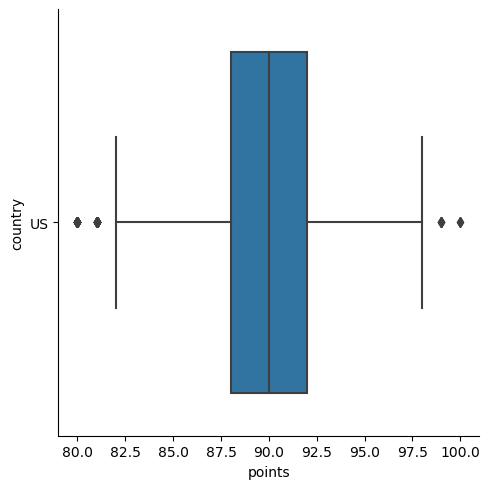

```python
sns.catplot(data=wine_complete,y='country',x='points', kind='box')
plt.show()
```

### 5e)

If you noticed, the two previous visualizations were created BEFORE examining the NUMBER OF UNIQUE values of `country` in the COMPLETE CASES data set. This step was skipped on purpose for this assignment!

Display the number of unique values for the variables (columns) in `wine_complete`.

#### 5e) - SOLUTION

```python
wine_complete.nunique()
```

```
Unnamed: 0               22387
country                      1
description              20491
designation               9515
points                      21
price                      146
province                     4
region_1                   171
region_2                    17
taster_name                 11
taster_twitter_handle       11
title                    20425
variety                    183
winery                    2791
dtype: int64
```

### 5f)

Why does the number of unique values of `country` explain the behavior of the two figures created in Problem 5?

What happened when MISSINGS were dropped to create the COMPLETE CASES? Type your response in a markdown cell below.

#### 5f) - SOLUTION

What do you think?

The number of unique value of the country tells us only one coutry in the wine_complet, that's why we only saw one box and one bar in the two figures.when drop the missing to create the complete case, only one coutry was left.

## Problem 06

Let's now perform one more important data manipulation action in this assignment. You will practice **reshaping** data from WIDE FORMAT to LONG FORMAT. This will help you explore multiple variables easier.

You will use another Tidy Tuesday data set for this practice. The cell below defines the `crops_url` object for you. This object is a string and provides the download link to the "raw" Global Crop Yields data.

```python
crops_url = 'https://raw.githubusercontent.com/rfordatascience/tidytuesday/master/data/2020/2020-09-01/key_crop_yields.csv'
```

### 6a)

Use the `pd.read_csv()` function to read the crops data from the Github repo webpage. Assign the result to the `crops` object.

Display the `.info()` method of `crops` to the screen.

#### 6a) - SOLUTION

```python
crops=pd.read_csv(crops_url)
```

```python
crops.info()
```

```
<class 'pandas.core.frame.DataFrame'>
RangeIndex: 13075 entries, 0 to 13074
Data columns (total 14 columns):
 #   Column                            Non-Null Count  Dtype
---  ------                            --------------  -----
 0   Entity                            13075 non-null  object
 1   Code                              11156 non-null  object
 2   Year                              13075 non-null  int64
 3   Wheat (tonnes per hectare)        8101 non-null   float64
 4   Rice (tonnes per hectare)         8471 non-null   float64
 5   Maize (tonnes per hectare)        10774 non-null  float64
 6   Soybeans (tonnes per hectare)     5961 non-null   float64
 7   Potatoes (tonnes per hectare)     10016 non-null  float64
 8   Beans (tonnes per hectare)        8009 non-null   float64
 9   Peas (tonnes per hectare)         6235 non-null   float64
 10  Cassava (tonnes per hectare)      7188 non-null   float64
 11  Barley (tonnes per hectare)       6733 non-null   float64
 12  Cocoa beans (tonnes per hectare)  4609 non-null   float64
 13  Bananas (tonnes per hectare)      8909 non-null   float64
dtypes: float64(11), int64(1), object(2)
memory usage: 1.4+ MB
```

### 6b)

The `.info()` method reveals `crops` has multiple numeric (number) columns! It would be tedious to manually create histograms to visualize the **marginal distributions** associated with numeric (number) column. You will therefore use reshaping to streamline the visualization!

However, you need to identify all numeric (number) columns to support the reshaping.

Create a list that contains the names for all numeric (number) columns in the `crops` data set. Assign the result to the `crops_number_vars` object. Display the list to the screen to confirm it contains all numeric (number) column names.

*HINT*: A Pandas method can select columns based on data type...

#### 6b) - SOLUTION

```python
crops_number_vars=crops.select_dtypes('number').copy()
```

```python
crops_number_vars
```

|  | Year | Wheat (tonnes per hectare) | Rice (tonnes per hectare) | Maize (tonnes per hectare) | Soybeans (tonnes per hectare) | Potatoes (tonnes per hectare) | Beans (tonnes per hectare) | Peas (tonnes per hectare) | Cassava (tonnes per hectare) | Barley (tonnes per hectare) | Cocoa beans (tonnes per hectare) | Bananas (tonnes per hectare) |
| --- | --- | --- | --- | --- | --- | --- | --- | --- | --- | --- | --- | --- |
| 0 | 1961 | 1.0220 | 1.5190 | 1.4000 | NaN | 8.6667 | NaN | NaN | NaN | 1.0800 | NaN | NaN |
| 1 | 1962 | 0.9735 | 1.5190 | 1.4000 | NaN | 7.6667 | NaN | NaN | NaN | 1.0800 | NaN | NaN |
| 2 | 1963 | 0.8317 | 1.5190 | 1.4260 | NaN | 8.1333 | NaN | NaN | NaN | 1.0800 | NaN | NaN |
| 3 | 1964 | 0.9510 | 1.7273 | 1.4257 | NaN | 8.6000 | NaN | NaN | NaN | 1.0857 | NaN | NaN |
| 4 | 1965 | 0.9723 | 1.7273 | 1.4400 | NaN | 8.8000 | NaN | NaN | NaN | 1.0857 | NaN | NaN |
| ... | ... | ... | ... | ... | ... | ... | ... | ... | ... | ... | ... | ... |
| 13070 | 2014 | 2.2094 | 2.2663 | 0.9301 | 1.1767 | 16.7726 | 0.4563 | NaN | 4.6266 | 5.4610 | NaN | 6.8036 |
| 13071 | 2015 | 2.0486 | 2.2689 | 0.5803 | 0.9459 | 16.9360 | 0.4145 | NaN | 4.6818 | 5.4620 | NaN | 7.1862 |
| 13072 | 2016 | 1.9013 | 2.2671 | 0.4405 | 1.1958 | 17.0007 | 0.3574 | NaN | 4.7117 | 5.4727 | NaN | 7.4281 |
| 13073 | 2017 | 1.7542 | 2.2656 | 0.5589 | 1.5139 | 17.0545 | 0.5316 | NaN | 4.7420 | 5.4811 | NaN | 7.6618 |
| 13074 | 2018 | 2.0010 | 2.2641 | 0.6131 | 1.5000 | 17.1083 | 0.4773 | NaN | 4.7705 | 5.4894 | NaN | 7.8955 |

13075 rows × 12 columns

### 6c)

You must now **reshape** `crops` from WIDE FORMAT to LONG FORMAT by "stacking" all numeric columns on top of each other. Assign the result to the `crops_lf` object. The LONG FORMAT object **must** include a column named `rowid` which identifies the original WIDE FORMAT row number in `crops`.

Apply the `.info()` method to `crops_lf` and display the result to the screen.

#### 6c) - SOLUTION

```python
crops_lf=crops.reset_index().rename(columns={'index':'rowid'}).\
melt(id_vars=['rowid','Entity','Code'], value_vars=crops_number_vars,ignore_index =True)
```

```python
crops_lf
```

|  | rowid | Entity | Code | variable | value |
| --- | --- | --- | --- | --- | --- |
| 0 | 0 | Afghanistan | AFG | Year | 1961.0000 |
| 1 | 1 | Afghanistan | AFG | Year | 1962.0000 |
| 2 | 2 | Afghanistan | AFG | Year | 1963.0000 |
| 3 | 3 | Afghanistan | AFG | Year | 1964.0000 |
| 4 | 4 | Afghanistan | AFG | Year | 1965.0000 |
| ... | ... | ... | ... | ... | ... |
| 156895 | 13070 | Zimbabwe | ZWE | Bananas (tonnes per hectare) | 6.8036 |
| 156896 | 13071 | Zimbabwe | ZWE | Bananas (tonnes per hectare) | 7.1862 |
| 156897 | 13072 | Zimbabwe | ZWE | Bananas (tonnes per hectare) | 7.4281 |
| 156898 | 13073 | Zimbabwe | ZWE | Bananas (tonnes per hectare) | 7.6618 |
| 156899 | 13074 | Zimbabwe | ZWE | Bananas (tonnes per hectare) | 7.8955 |

156900 rows × 5 columns

### 6d)

Let's now visualize histograms for ALL numeric columns within a single figure! You MUST use the Seaborn FIGURE LEVEL function `sns.displot()` to create the visualization. The COLUMN facets must be associated with each **variable** and you must 6 facets per row. The facets **must** use separate `x` and `y` axis scales and thus the axes must be **free**. The `common_bins` argument **must** be set to `False`.

**IMPORANT**: if the figure is taking a LONG TIME...check that the arguments are set correctly!

#### 6d) - SOLUTION

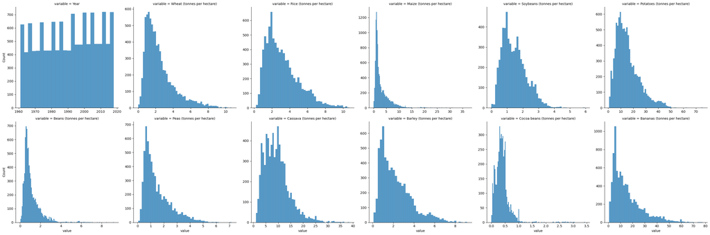

```python
sns.displot(data=crops_lf,x='value',col='variable',
            kind='hist',col_wrap=6,
            facet_kws={'sharex': False, 'sharey': False},
            common_bins=False
            )
plt.show()
```

### 6e)

What do the histograms of all crop related variables have in common as shown by the faceted histogram in 6d)? The crop related variables do not include `Year`. Type your response in the markdown cell below.

#### 6e) - SOLUTION

What do you think?

The faceted histogram in 6d) shows us that the crop yields are all right skewed, all of them have of long right tails.

## Problem 07

You will work on a final project of your own choosing this semester! That means you must find data associated with a project that interests you! Let's get some practice by READING in data from Tidy Tuesday. However, you get the choose the data to read in! The only rule is that you cannot read in the Spotify Songs data (used in lecture) or either of the two data sets used in this assignment.

You only need to read in 1 data set for this problem. You do NOT need to visually explore the data. You are only required to show the ESSENTIAL EDA INFORMATION associated with the data! Therefore you must display for the data of your choosing:

- The number of rows and columns
- The names of the columns
- The data type associated with each column
- The number of unique values for each column
- The number of missing entries for each column

Again you do NOT need to do anything else for this question. This is just to practice reading in data of your own choosing. Hopefully, this assignment reinforced why such information is so important to data exploration!

#### 7) - SOLUTION

```python
spam_url ='https://raw.githubusercontent.com/rfordatascience/tidytuesday/master/data/2023/2023-08-15/spam.csv'
```

```python
spam=pd.read_csv(spam_url)
```

```python
spam
```

|  | crl.tot | dollar | bang | money | n000 | make | yesno |
| --- | --- | --- | --- | --- | --- | --- | --- |
| 0 | 278 | 0.000 | 0.778 | 0.00 | 0.00 | 0.00 | y |
| 1 | 1028 | 0.180 | 0.372 | 0.43 | 0.43 | 0.21 | y |
| 2 | 2259 | 0.184 | 0.276 | 0.06 | 1.16 | 0.06 | y |
| 3 | 191 | 0.000 | 0.137 | 0.00 | 0.00 | 0.00 | y |
| 4 | 191 | 0.000 | 0.135 | 0.00 | 0.00 | 0.00 | y |
| ... | ... | ... | ... | ... | ... | ... | ... |
| 4596 | 88 | 0.000 | 0.000 | 0.00 | 0.00 | 0.31 | n |
| 4597 | 14 | 0.000 | 0.353 | 0.00 | 0.00 | 0.00 | n |
| 4598 | 118 | 0.000 | 0.000 | 0.00 | 0.00 | 0.30 | n |
| 4599 | 78 | 0.000 | 0.000 | 0.00 | 0.00 | 0.96 | n |
| 4600 | 40 | 0.000 | 0.125 | 0.00 | 0.00 | 0.00 | n |

4601 rows × 7 columns

```python
# number of rows and columns
spam.shape
```

```
(4601, 7)
```

```python
# The names of the columns
spam.columns
```

```
Index(['crl.tot', 'dollar', 'bang', 'money', 'n000', 'make', 'yesno'], dtype='object')
```

```python
# The data type associated with each column
spam.dtypes
```

```
crl.tot      int64
dollar     float64
bang       float64
money      float64
n000       float64
make       float64
yesno       object
dtype: object
```

```python
# The number of unique values for each column
spam.nunique()
```

```
crl.tot    919
dollar     504
bang       964
money      143
n000       164
make       142
yesno        2
dtype: int64
```

```python
# The number of missing entries for each column
spam.isna().sum()
```

```
crl.tot    0
dollar     0
bang       0
money      0
n000       0
make       0
yesno      0
dtype: int64
```